# Reproducible Research: Peer Assessment 1

Kirsten Smith

## Loading required packages

```r
library(knitr)
library(ggplot2)
```

## Loading and preprocessing the data

Please note that the script expects a file called “activity.zip” in the same directory as the script itself.

```r
unzip("activity.zip")
data <- read.csv("activity.csv")
data$date <- as.POSIXct(data$date, format = "%Y-%m-%d")
```

Sample of 10 rows from the data set:

```r
kable(data[2303:2312,],align='c')
```

|  | steps | date | interval |
| --- | --- | --- | --- |
| 2303 | NA | 2012-10-08 | 2350 |
| 2304 | NA | 2012-10-08 | 2355 |
| 2305 | 0 | 2012-10-09 | 0 |
| 2306 | 0 | 2012-10-09 | 5 |
| 2307 | 0 | 2012-10-09 | 10 |
| 2308 | 0 | 2012-10-09 | 15 |
| 2309 | 0 | 2012-10-09 | 20 |
| 2310 | 13 | 2012-10-09 | 25 |
| 2311 | 28 | 2012-10-09 | 30 |
| 2312 | 0 | 2012-10-09 | 35 |

## What is mean total number of steps taken per day?

Creating a version of the data aggregated by day:

```r
daily_total <- aggregate(x=data$steps, by=list(data$date), sum, na.rm=TRUE)
colnames(daily_total) <- c("date","total.steps")
daily_total$month <- months(daily_total$date)
```

Taking a look at the daily totals:

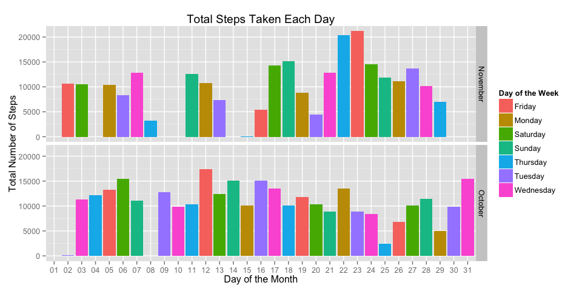

```r
ggplot(daily_total, aes(x=format(date, "%d"),y=total.steps, fill=weekdays(date))) + geom_bar(stat="identity") + ylab("Total Number of Steps") + xlab("Day of the Month") + ggtitle("Total Steps Taken Each Day") + facet_grid(month ~ .) + scale_fill_discrete("Day of the Week")
```

As per assignment, putting together a histogram of the number of steps each day:

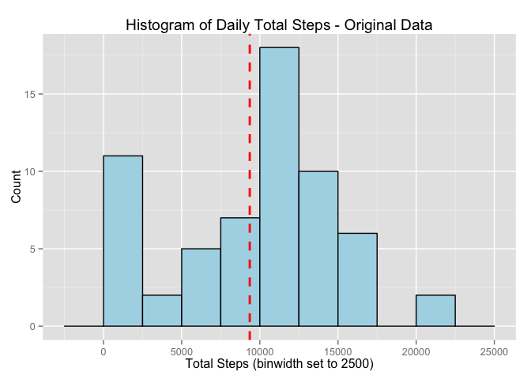

```r
ggplot(daily_total, aes(x=total.steps)) + geom_histogram(binwidth = 2500, colour="black", fill="light blue") + ggtitle("Histogram of Daily Total Steps - Original Data") + ylab("Count") + xlab("Total Steps (binwidth set to 2500)") + geom_vline(aes(xintercept=mean(total.steps, na.rm=TRUE)), color="red", linetype="dashed", size=1)
```

The overall daily average is:

```r
mean(daily_total$total.steps, na.rm=TRUE)
```

```
## [1] 9354.23
```

The overall daily median is:

```r
median(daily_total$total.steps, na.rm=TRUE)
```

```
## [1] 10395
```

## What is the average daily activity pattern?

Aggregate the data by interval means instead of daily total:

```r
interval_means <- aggregate(x=data$steps, by=list(data$interval), mean, na.rm=TRUE)
colnames(interval_means) <- c("interval","avg.steps")
```

Plot the average time series data for a day:

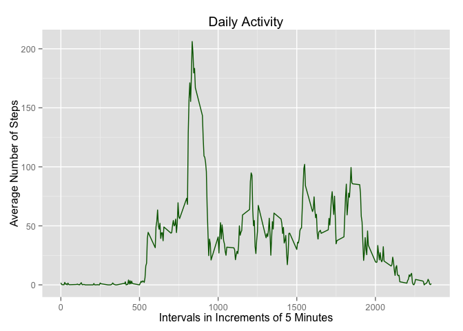

```r
ggplot(interval_means, aes(x=interval,y=avg.steps)) + geom_line(color="dark green") + ylab("Average Number of Steps") + xlab("Intervals in Increments of 5 Minutes") + ggtitle("Daily Activity")
```

Highest average number of steps is at:

```r
step_max <- interval_means[interval_means$avg.steps == max(interval_means$avg.steps),]
kable(step_max,row.names = FALSE)
```

| interval | avg.steps |
| --- | --- |
| 835 | 206.1698 |

## Imputing missing values

Total number of rows with missing values is:

```r
sum(is.na(data$steps))
```

```
## [1] 2304
```

We will now supplement the missing values with the average number of steps for that interval (found in the average daily activity pattern) by iterating through all rows of the data set. Same rows are shown in the 10 row data sample:

```r
#iterating through data to replace NAs
supplemented <- data
for(i in 1:nrow(supplemented)) {
    if(is.na(supplemented$steps[i])) {
        supplemented$steps[i] <-         interval_means[which(interval_means$interval==supplemented$interval[i]),]$avg.steps
        }
}

#display table of new sample data
kable(supplemented[2303:2312,], align='c', row.names = TRUE)
```

|  | steps | date | interval |
| --- | --- | --- | --- |
| 2303 | 0.2264151 | 2012-10-08 | 2350 |
| 2304 | 1.0754717 | 2012-10-08 | 2355 |
| 2305 | 0.0000000 | 2012-10-09 | 0 |
| 2306 | 0.0000000 | 2012-10-09 | 5 |
| 2307 | 0.0000000 | 2012-10-09 | 10 |
| 2308 | 0.0000000 | 2012-10-09 | 15 |
| 2309 | 0.0000000 | 2012-10-09 | 20 |
| 2310 | 13.0000000 | 2012-10-09 | 25 |
| 2311 | 28.0000000 | 2012-10-09 | 30 |
| 2312 | 0.0000000 | 2012-10-09 | 35 |

```r
#create daily aggregates
daily_total_supplemented <- aggregate(x=supplemented$steps, by=list(supplemented$date), sum, na.rm=TRUE)
colnames(daily_total_supplemented) <- c("date","total.steps")
```

Rerunning the code to create the histogram but now with the supplemented data set:

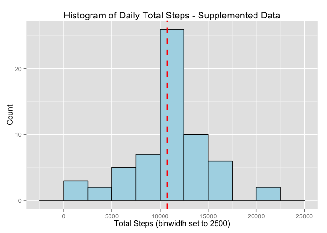

```r
ggplot(daily_total_supplemented, aes(x=total.steps)) + geom_histogram(binwidth = 2500, colour="black", fill="light blue") + ggtitle("Histogram of Daily Total Steps - Supplemented Data") + ylab("Count") + xlab("Total Steps (binwidth set to 2500)") + geom_vline(aes(xintercept=mean(total.steps, na.rm=TRUE)), color="red", linetype="dashed", size=1)
```

The overall daily average for the supplemented data is:

```r
mean(daily_total_supplemented$total.steps, na.rm=TRUE)
```

```
## [1] 10766.19
```

The overall daily median is:

```r
median(daily_total_supplemented$total.steps, na.rm=TRUE)
```

```
## [1] 10766.19
```

In the histogram it is probably the easiest to see how there is no longer a very large category with a low number of steps and this has caused the mean and median values to be closer to each other.

## Are there differences in activity patterns between weekdays and weekends?

Create a function to calculate whether a day is a weekday or a weekend day and iterate over data set:

```r
daytype <- function(x) {
    day <- weekdays(x)
    if(day=="Saturday" || day=="Sunday") {
        return("Weekend")
    } else {
        return("Weekday")
    }
}

for(i in 1:nrow(supplemented)) {
    supplemented$day.type[i] <- daytype(supplemented$date[i])
}
```

Aggregate the data by taking the average for each interval & day type:

```r
interval_means_supplemented <- aggregate(x=supplemented$steps, by=list(supplemented$interval,supplemented$day.type), mean, na.rm=TRUE)
colnames(interval_means_supplemented) <- c("interval","day.type","avg.steps")
```

Comparing daily activity for weekdays vs weekend days:

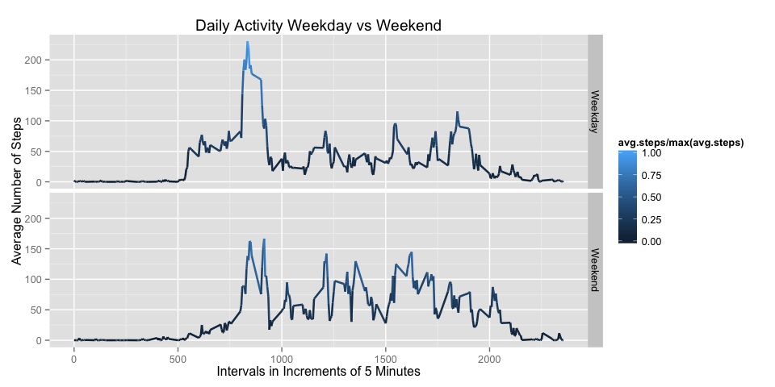

```r
ggplot(interval_means_supplemented, aes(x=interval,y=avg.steps, color=avg.steps/max(avg.steps))) + geom_line(size=0.9) + ylab("Average Number of Steps") + xlab("Intervals in Increments of 5 Minutes") + ggtitle("Daily Activity Weekday vs Weekend") + facet_grid(day.type ~ .)
```